# IUPred3 for disorder analysis

There is also an R package that can be used to calculate the IUPred score, however it uses the old version of IUPred and it also takes a very long time to load. (Though the Python script also took ~ 7 hours to execute)

[IUPred Vignette (bioconductor.org)](https://bioconductor.org/packages/release/bioc/vignettes/idpr/inst/doc/iupred-vignette.html)

**Python scripts**

- A Python script was used to calculate the stability scores for all of the proteins using IUPred3.
- `IUPred_score_calc_frac` was used to calculate the score as the number of amino acids above the threshold (0.5 was used since this was the default) over the total number of amino acids.
- `iupred.slurm` was used to run the file on the HPC.
- `uniprot_ids_proteins.tsv` was the input file used. It contains the list of all the proteins that are present in the re-analysed dataset. [18929 proteins]

# Distribution of IUPred3 scores

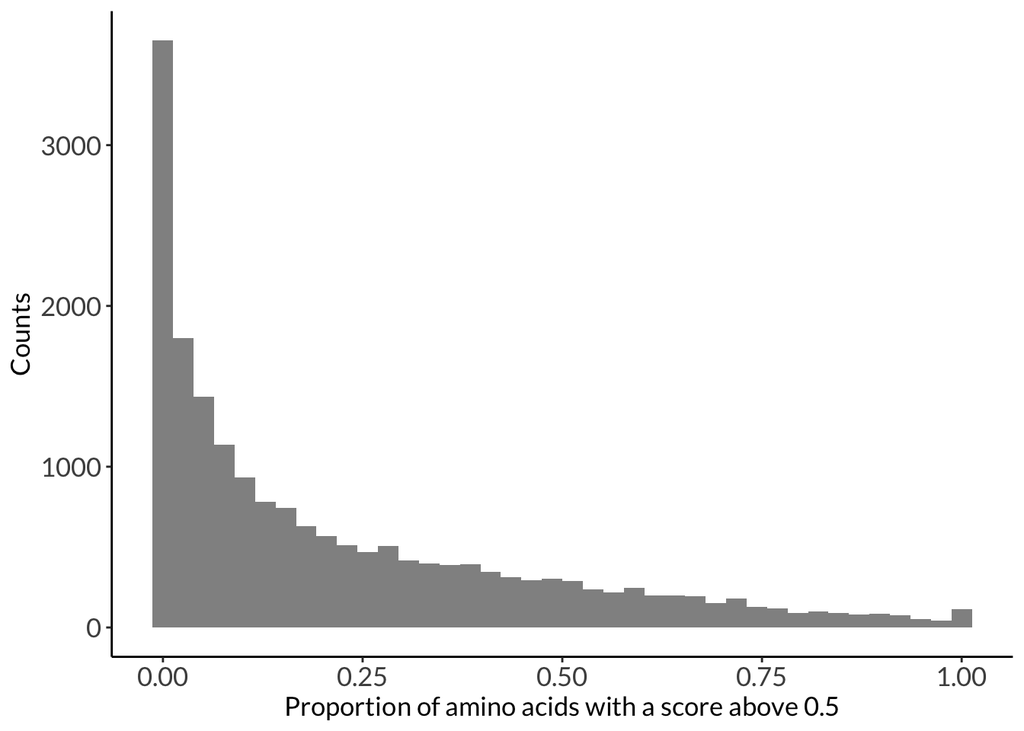

# Outliers

Removing proteins with too many modifications.

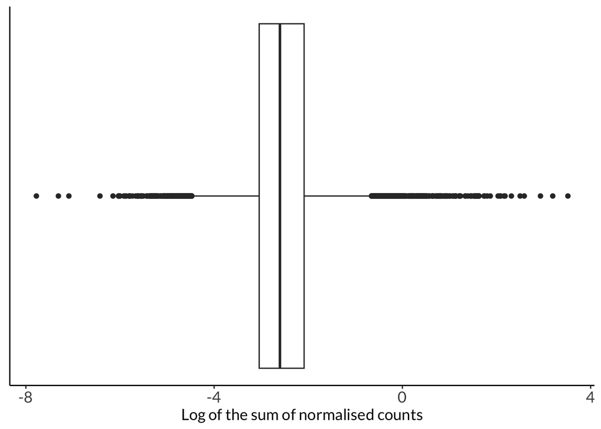

Phosphorylation violin plot

## Distributions

### Phoshorylation

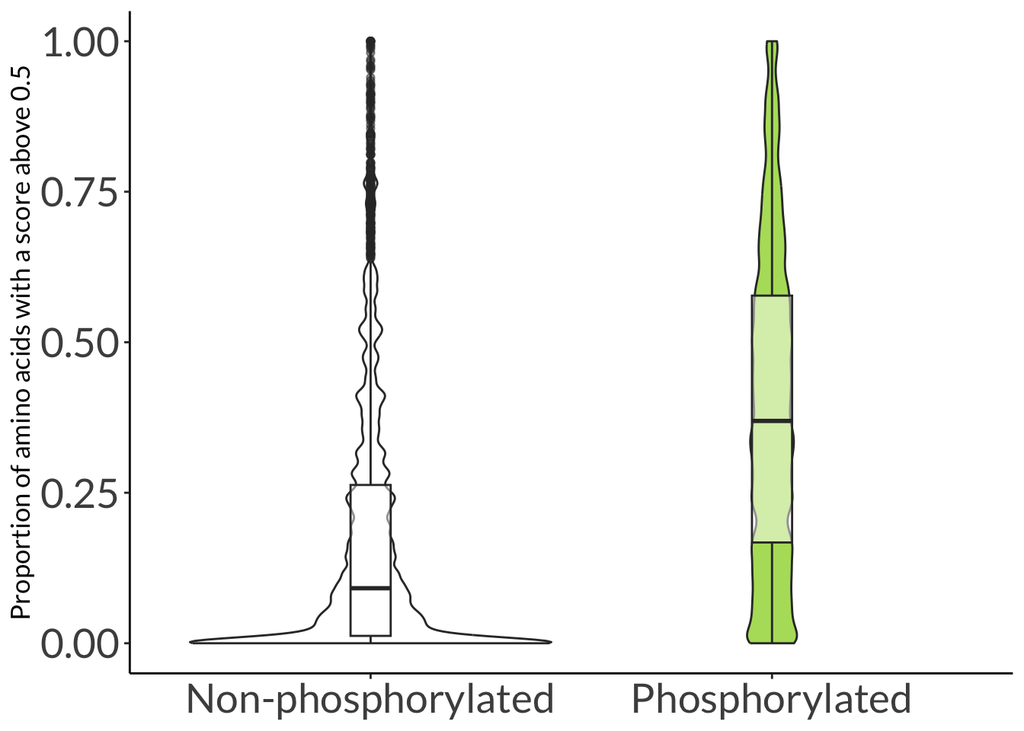

```
[1] "Non-modified"
```

```
[1] 5177    4
```

```
[1] "Modified"
```

```
[1] 9775    4
```

```
    Design-based KruskalWallis test

data:  Ratio_Above_0.5 ~ mod_group
t = 19.138, df = 14950, p-value < 2.2e-16
alternative hypothesis: true difference in mean rank score is not equal to 0
sample estimates:
difference in mean rank score
                    0.2504197
```

```
[1] "adjusted p-value"
```

```
gPhosphorylated
   1.379983e-79
```

```
[1] 14952     4
```

### Acetylation

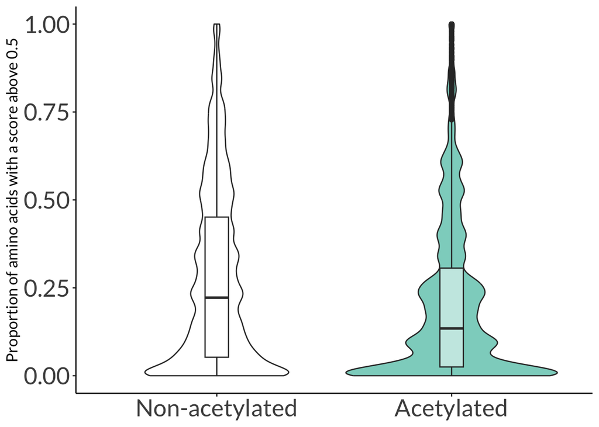

```
[1] "Non-modified"
```

```
[1] 7279    4
```

```
[1] "Modified"
```

```
[1] 7673    4
```

```
    Design-based KruskalWallis test

data:  Ratio_Above_0.5 ~ mod_group
t = -3.7312, df = 14950, p-value = 0.0001912
alternative hypothesis: true difference in mean rank score is not equal to 0
sample estimates:
difference in mean rank score
                  -0.08309744
```

```
[1] "adjusted p-value"
```

```
gAcetylated
 0.00233843
```

```
[1] 14952     4
```

### Ubiquitination

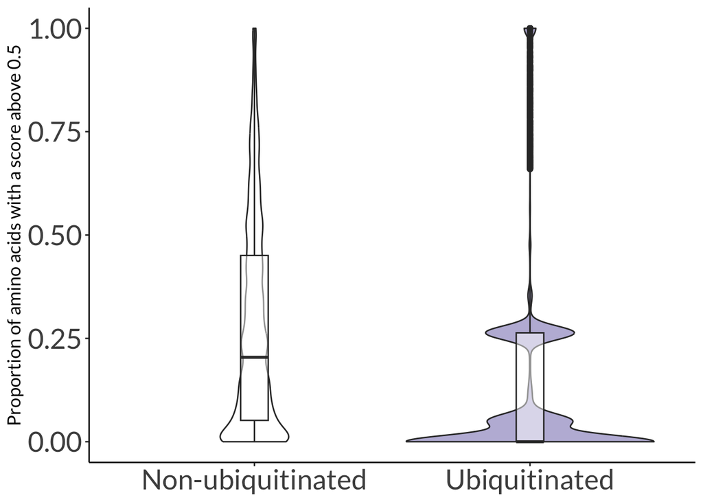

```
[1] "Non-modified"
```

```
[1] 5942    4
```

```
[1] "Modified"
```

```
[1] 9206    4
```

```
    Design-based KruskalWallis test

data:  Ratio_Above_0.5 ~ mod_group
t = -1.8489, df = 15146, p-value = 0.06449
alternative hypothesis: true difference in mean rank score is not equal to 0
sample estimates:
difference in mean rank score
                   -0.2611965
```

```
[1] "adjusted p-value"
```

```
gUbiquitinated
     0.7936831
```

```
[1] 15148     4
```

### Methylation

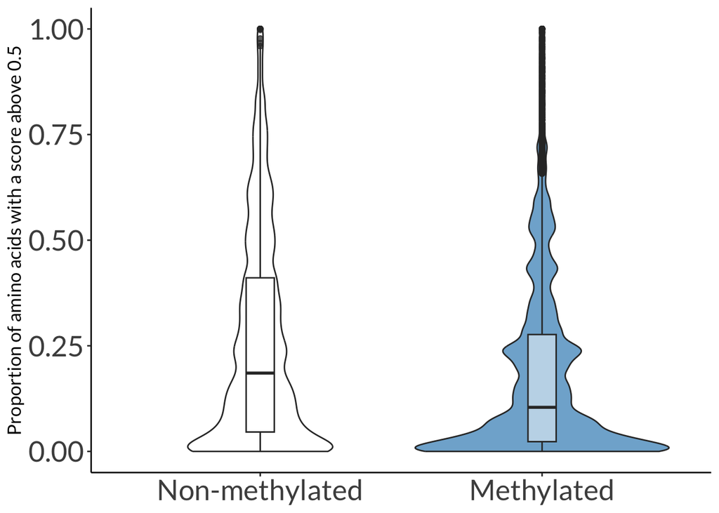

```
[1] "Non-modified"
```

```
[1] 5120    4
```

```
[1] "Modified"
```

```
[1] 9832    4
```

```
    Design-based KruskalWallis test

data:  Ratio_Above_0.5 ~ mod_group
t = -4.3702, df = 14950, p-value = 1.25e-05
alternative hypothesis: true difference in mean rank score is not equal to 0
sample estimates:
difference in mean rank score
                    -0.086543
```

```
[1] "adjusted p-value"
```

```
gMethylated
0.000152818
```

```
[1] 14952     4
```

### oxPTMs

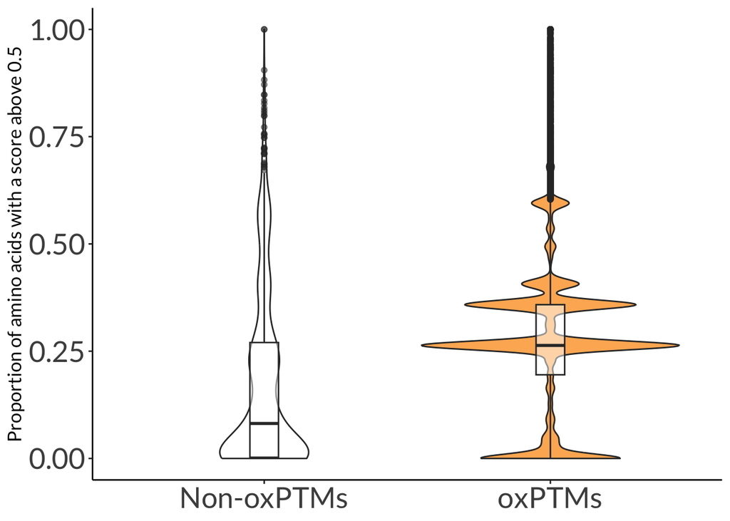

```
[1] "Non-modified"
```

```
[1] 761   4
```

```
[1] "Modified"
```

```
[1] 15316     4
```

```
    Design-based KruskalWallis test

data:  Ratio_Above_0.5 ~ mod_group
t = 1.9077, df = 16075, p-value = 0.05644
alternative hypothesis: true difference in mean rank score is not equal to 0
sample estimates:
difference in mean rank score
                    0.1565927
```

```
[1] "adjusted p-value"
```

```
  goxPTMs
0.7156545
```

```
[1] 16077     4
```

### Lysine acylations

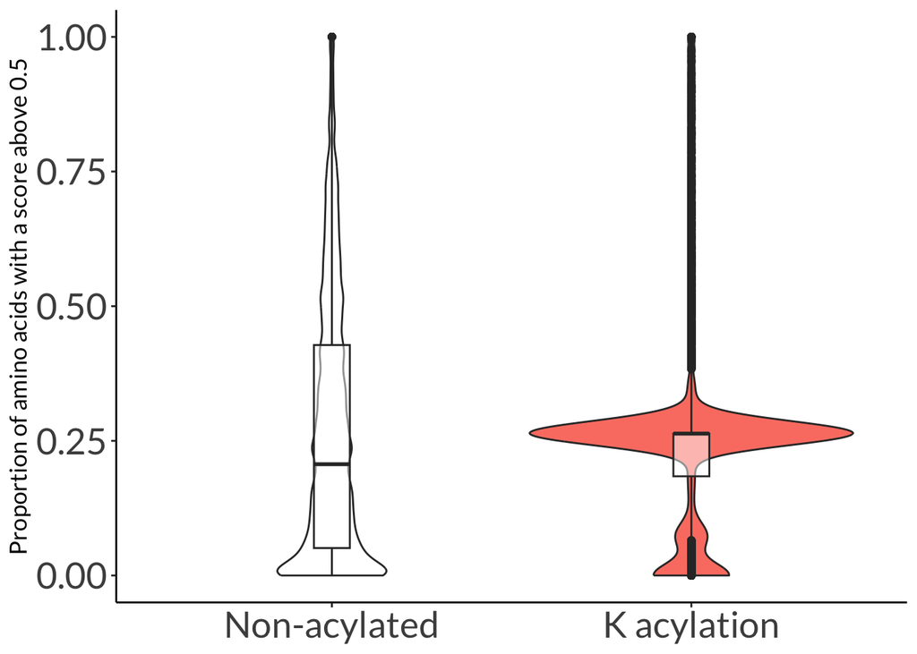

```
[1] "Non-modified"
```

```
[1] 8281    4
```

```
[1] "Modified"
```

```
[1] 6794    4
```

```
    Design-based KruskalWallis test

data:  Ratio_Above_0.5 ~ mod_group
t = -1.1619, df = 15073, p-value = 0.2453
alternative hypothesis: true difference in mean rank score is not equal to 0
sample estimates:
difference in mean rank score
                  -0.06900675
```

```
[1] "adjusted p-value"
```

```
gK acylation
     3.01151
```

```
[1] 15075     4
```

### AGEs

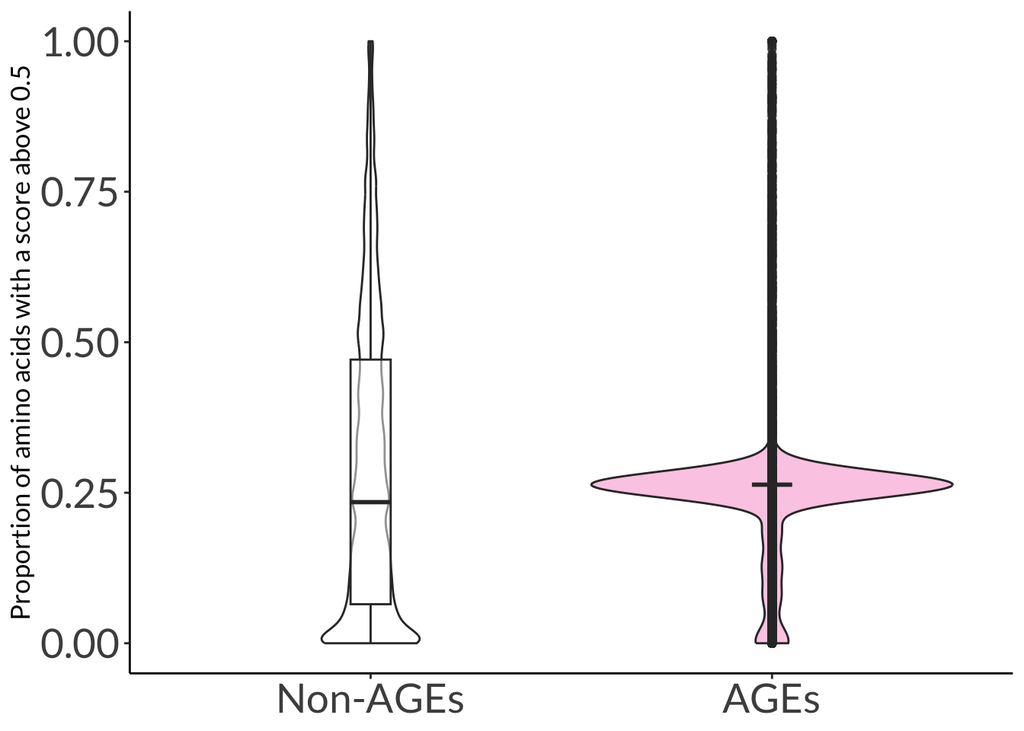

```
[1] "Non-modified"
```

```
[1] 10106     4
```

```
[1] "Modified"
```

```
[1] 4923    4
```

```
    Design-based KruskalWallis test

data:  Ratio_Above_0.5 ~ mod_group
t = -1.3154, df = 15027, p-value = 0.1884
alternative hypothesis: true difference in mean rank score is not equal to 0
sample estimates:
difference in mean rank score
                  -0.05556142
```

```
[1] "adjusted p-value"
```

```
   gAGEs
2.309572
```

```
[1] 15029     4
```

# Binning

This is only for PTMs, so the columns don’t need to actually add up.

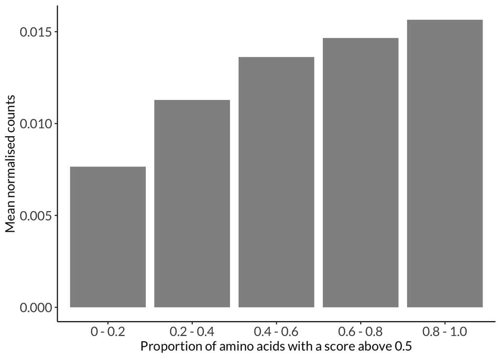

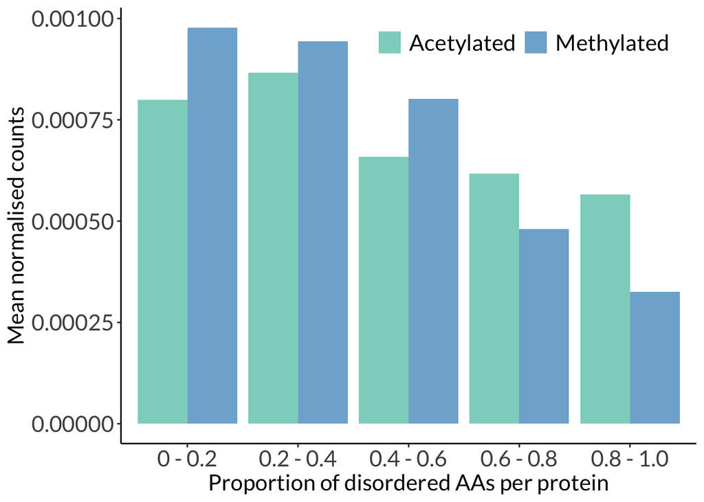

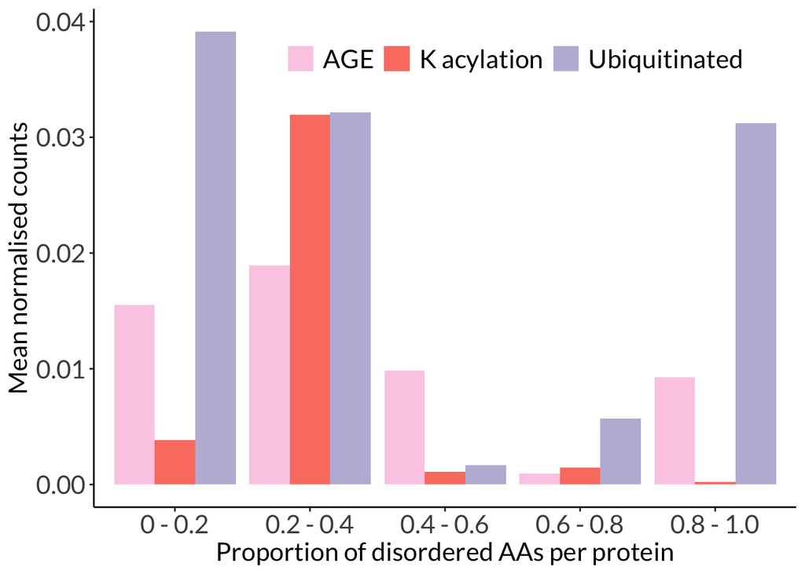

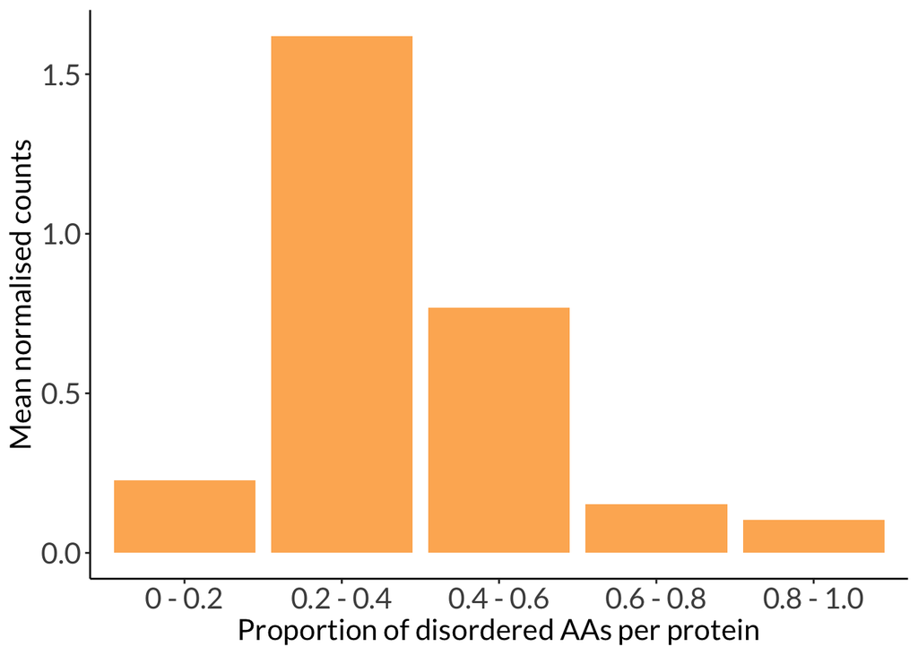

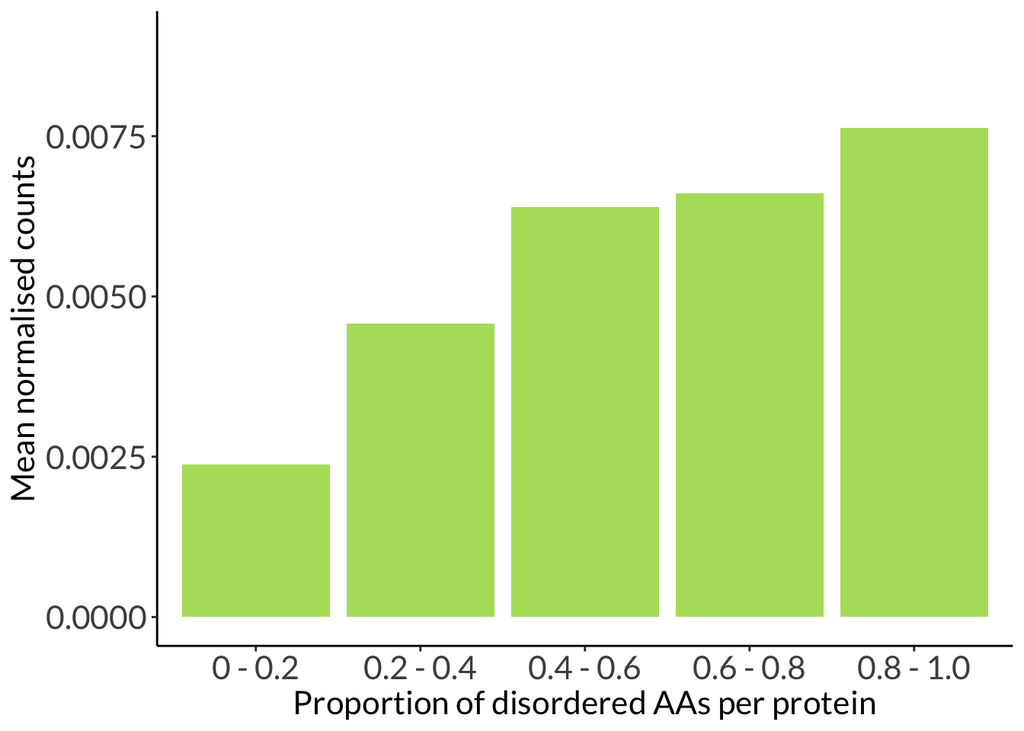